# Graphs in R using plot(): Symbols, Line Types and Colours

⇦ Back

# 1 Symbols

By default, there are 26 symbols that can be used for the data points of a scatter plot. These are set using the `pch` keyword argument and are numbered from 0 to 25, for example:  
`plot(x, y, pch = 0)`  
will plot with squares while  
`plot(x, y, pch = 1)`  
will plot with circles, and so on.

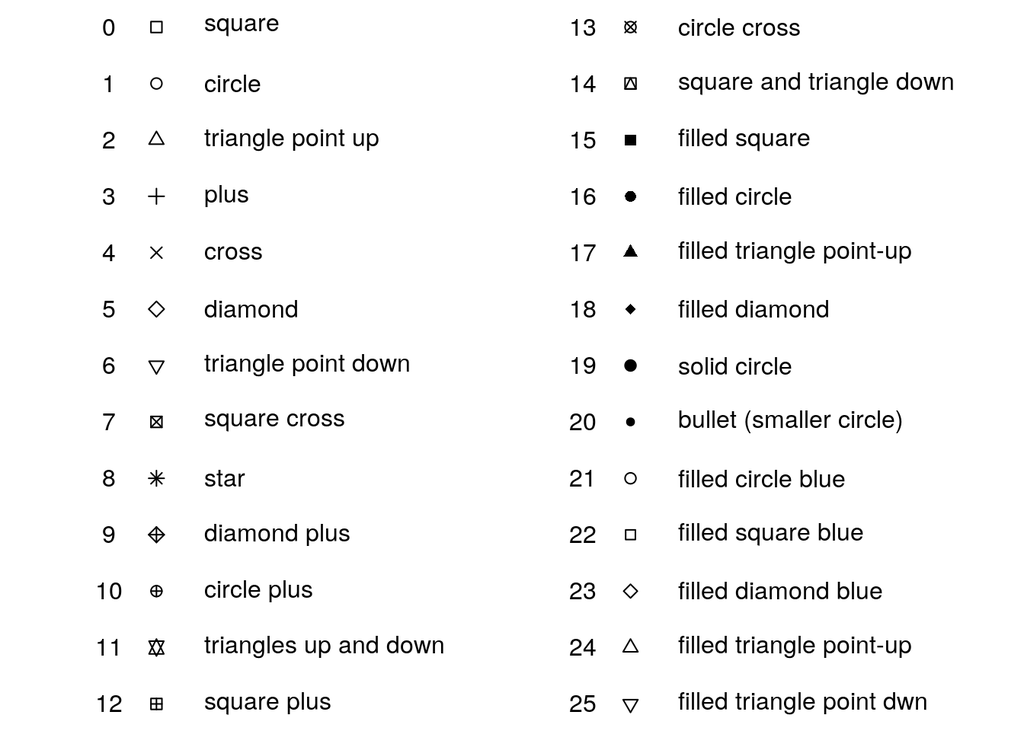

```r
num_symbols <- 26
nrows <- 13
ncols <- 2
# SET THE MARGINS OF THE PLOTTING AREA
par(mar = c(0, 0, 0, 0))
# PLOT
x <- c()
y <- c()
for (i in 0:25) {
    x <- c(x, ceiling((i + 1) / nrows))
    y <- c(y, nrows - (i %% nrows))
}
plot(x, y, pch = 0:25, axes = FALSE, xlim = c(0.75, ncols + 0.75))
name <- c(
    "square", "circle", "triangle point up", "plus", "cross", "diamond",
    "triangle point down", "square cross", "star", "diamond plus",
    "circle plus", "triangles up and down", "square plus", "circle cross",
    "square and triangle down", "filled square", "filled circle",
    "filled triangle point-up", "filled diamond", "solid circle",
    "bullet (smaller circle)", "filled circle blue", "filled square blue",
    "filled diamond blue", "filled triangle point-up",
    "filled triangle point dwn"
)
text(x + 0.1, y, name, adj = 0)
text(x - 0.1, y, 0:25)
```

# 2 Line Types

The style of line that is plotted can be controlled with the `lty` keyword argument (**l**ine **ty**pe), for example:  
`plot(x, y, lty = "dashed", type = "l")`  
will plot a dashed line. Note that the `type` keyword argument needs to be set to `l` for a line to be plotted (only the points will be plotted by default - ie a scatter plot instead of a line plot). The line types that can be used are as follows:

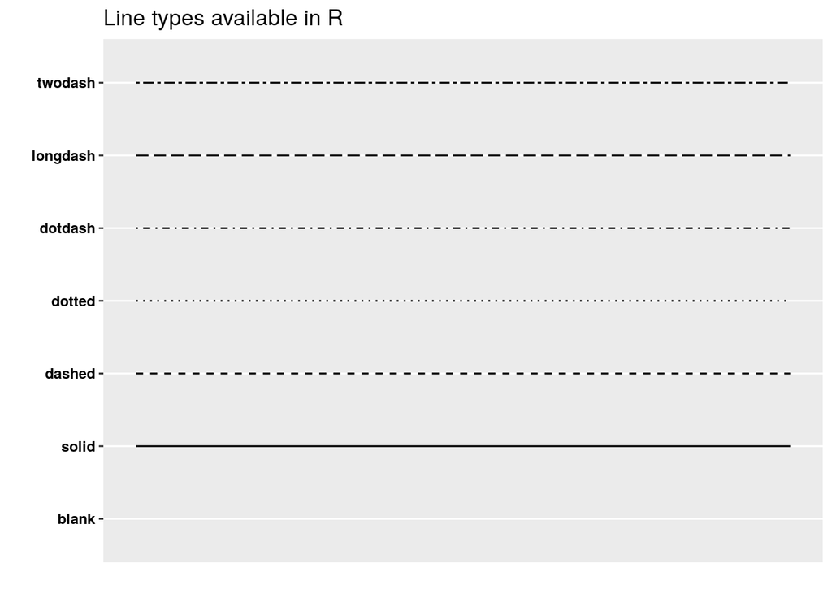

```r
library(ggpubr)
show_line_types()
```

# 3 Colours

There are 657 colours that can be referred to by name when choosing a colour for a plot. These are set using the `col` keyword argument, for example:  
`plot(x, y, col = "red")`  
will plot in red. The complete list is below:

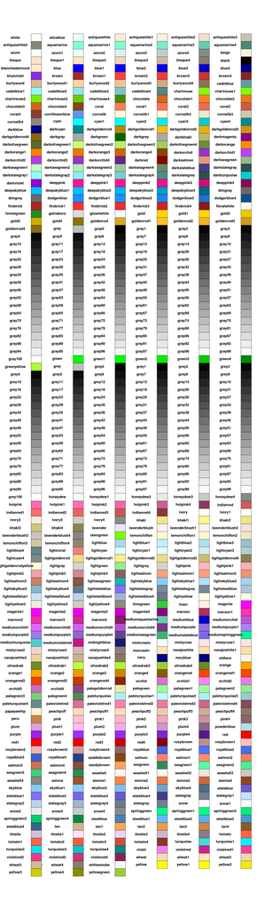

```r
num_colours <- 657
nrows <- 110
ncols <- 6
# SET THE MARGINS OF THE PLOTTING AREA
par(mar = c(0, 0, 0, 0))
# PLOT
plot(
    seq(1.5, 3.5, by = 2), seq(1.5, 3.5, by = 2),
    xlim = c(0, ncols * 2), ylim = c(0, nrows),
    xlab = NULL, ylab = NULL, xaxt = "n", yaxt = "n", axes = FALSE, ann = FALSE
)
xleft <- rep(seq(1, ncols * 2 - 1, by = 2), nrows)[1:num_colours]
ybottom <- c()
for (i in nrows:1 - 1) {
    ybottom <- c(ybottom, rep(i, ncols))
}
ybottom <- ybottom[1:num_colours]
xright <- rep(seq(1.5, ncols * 2 - 0.5, by = 2), nrows)[1:num_colours]
ytop <- c()
for (i in nrows:1) {
    ytop <- c(ytop, rep(i, ncols))
}
ytop <- ytop[1:num_colours]
rect(xleft, ybottom, xright, ytop, col = colors()[1:num_colours])
xtext <- rep(seq(0.25, ncols * 2 - 1.75, by = 2), nrows)[1:num_colours]
ytext <- c()
for (i in nrows:1 - 0.5) {
    ytext <- c(ytext, rep(i, ncols))
}
ytext <- ytext[1:num_colours]
text(xtext, ytext, colors()[1:num_colours], cex = 1.2, font = 2)
```

⇦ Back